# IDS 702 Team Black Project

Emma Wang, Pragya Raghuvanshi, Lorna Aine, Eric Rios Soderman

2022-10-21

# EXPLORING POPULARITY AND EXPLICITY OF 2010s MUSIC THROUGH MUSICALITY.

## I. Data Overview

The data set used in this research is a subset of a larger [spotify dataset](https://www.kaggle.com/datasets/yamaerenay/spotify-dataset-19212020-600k-tracks) that contained 586672 tracks. Our final subset of the data set of interest to our research problems contains 104767of observations/ tracks and 23 of variables for songs between 2010 and 2019. Our focus in this research is to infer which features of music are best associated to the popularity of songs and to predict if a song will be explicit or not based on these features.

After examining this data set, we decided on investigating two key problems of interest. One was gauging song popularity, and the other was predicting a song’s explicitness. For the former, we were profoundly intrigued by what song features or musical attributes effectively gauged and predicted a song’s popularity. For the latter, we focused on validating what features of a song best predicted if a song was likely to be explicit or non-explicit. Explicitness refers to the use of slurs and inappropriate words in a song. For both, we choose the variables based on prior domain knowledge.

Our Research Questions:

-What are the musical attributes that gauged the popularity of songs in the 2010s? *Dependent Variable (continuous) = popularity* *Independent Variables = acousticness, danceability, energy, instrumentation, tempo, loudness, and speechiness*

-To what extent can the musicality of a song predict whether a song will be explicit or non-explicit? *Dependent Variable (categorical) = Explicitness* *Independent Variables = danceability, energy, speechiness, and tempo*

## II.Primary relationship of interest

To better understand the various variables that gauge the musicality of a song, we will include the definitions of our main variables of interest, which were sourced from Spotify’s API documentation.

### Definitions of variables of interest

-**Popularity** is calculated by an algorithm that is based on how many times a track has been played and how recent those plays were. This is the response variable of interest for research question 1 (Spotify, 2022).

-**Explicitness** is whether a song contains inappropriate words such as curse words and sexually explicit words that are unacceptable to play in some public settings. 1 is the value identifying a song as explicit, while 0 implies that a song is non-explicit. This is the dependent variable for the second research question (Spotify, 2022).

-**Acousticness* is a confidence measure from 0.0 to 1.0 of how much of the track is composed with acoustic instruments. 1.0 represents high confidence the track is acoustic (Spotify, 2022).

-**Danceability** is a rating of a track’s suitability for dancing. This metric is based on a combination of musical elements including tempo, rhythm stability, beat strength, and overall regularity. A value of 0.0 is least danceable and 1.0 is most danceable (Spotify, 2022).

-**Energy* is a perceptual measure of intensity and activity. Energetic tracks typically feel fast, loud, and noisy (Spotify, 2022).

-**Instrumentation** pertains to whether a track contains no vocals. “Ooh” and “aah” sounds are treated as instrumentals in this context, while Rap or spoken word tracks are considered “vocal”. As the instrumentalness value approaches 1.0, there is a greater likelihood that the track contains no vocal content. In addition, values above 0.5 are intended to represent instrumental tracks, but confidence is higher as the value approaches 1.0 (Spotify, 2022).

-**Tempo** refers to the overall estimated tempo of a track in beats per minute (BPM). In musical terminology, tempo is the speed or pace of a given piece, which derives directly from the average beat duration (Spotify, 2022).

-**Loudness** measures the overall loudness of a track in decibels (dB). Loudness values are averaged across the entire track and are useful for comparing relative loudness of tracks. Loudness is the quality of a sound that is the primary psychological association of physical strength (amplitude). Lastly, the values typically range between -60 and 0 db (Spotify, 2022).

-**Speechiness** detects the presence of spoken words in a track. The more exclusively speech-like the recording (e.g. talk show, audio book, poetry), the closer to 1.0 the attribute value. Values above 0.66 describe tracks that are probably made entirely of spoken words. Values between 0.33 and 0.66 describe tracks that may contain both music and speech, either in sections or layered, including such cases as rap music. Values below 0.33 most likely represent music and other non-speech-like tracks (Spotify, 2022).

### Justification for Variable Selection

First and foremost, we chose the variables for our research questions based on prior, domain knowledge of musical terminology. For the first research question, which concerns the features that popularized songs during the 2010s, a series of aforementioned predictors were chosen. What will follow is the justification for this “a priori” selection for both research questions.

The reasoning for choosing these specific predictors (acousticness, danceability, energy, instrumentation, tempo, loudness, and speechiness) to predict song popularity is the weight of their importance. Popular songs, whether they are an emotional ballad or a dance track, all have certain features to keep the listeners engaged and interested to repeat listening to these tracks (Leviatan, 2017). The tempo, energy and loudness indicate the pacing and sonic impact and pleasantness of the track. The speechiness, danceability and instrumentation (which also includes acoustic choices or “acousticness”) dictate melody choices, chord progressions, instrument choices, wordings, vocal lines and more types sonic layers. However, this last point is very nuanced because it pertains to the genre choice of the producers. There are very popular songs with high instrumentation, no words and low danceability, such as songs from classical music. On the other hand, Pop and Rock songs vary their levels of instrumentation and acousticness and speechiness to deliver the best possible songs. Lastly, if the song is aimed towards a festive audience, such as a club song, then prioritizing danceability governs the levels of instrumentation and speechiness and lack of acousticness, and this prioritization varies by genre (Androids, 2017). In conclusion, the interplay of these factors influence the popularity of songs by helping them become easily memorable and enticing.

As for the second research question, the explicitness of tracks is strongly swayed by other factors. A very logical approach to predicting explicitness was first looking at the high levels of speechiness in songs. For example, rap songs rank high in this metric because the verses are composed of a spoken word format over a series of 8 or 16 bars, and each bar is a rap line (Edwords), while singing doesn’t have to adhere to the “1 bar = 1 line” rule; thus, speechiness became the metric of most importance. In addition, songs in this genre tend to include explicit content, often sexual, in the lyrics (Tayag, 2017). Second to this metric, the other predictors of danceability, energy and tempo were considered as helpful in predicing explicitness. The energy and danceability of the song collude with speechiness to infer if a track could have explicit language. For example, a song with low energy and low danceability may or may not be less likely to have explicit language than a song with high energy and danceability, holding the speechiness level constant, and this is a relationship we wish to investigate as well. As for tempo, music genres that are known to include explicit language follow specific tempos. For instance, Trap songs usually have a tempo of 140 bpm (Burchell, 2019).

To fully understand the data with which we are working, we will explore the basic statistics of the variables of interest.

|  | Non-Explicit (N=92440) | Explicit (N=12327) | total (N=104767) |
| --- | --- | --- | --- |
| acousticness |  |  |  |
| Mean (SD) | 0.295 (0.300) | 0.227 (0.224) | 0.287 (0.293) |
| Median [Min, Max] | 0.181 [0, 0.996] | 0.151 [0.00000115, 0.993] | 0.176 [0, 0.996] |
| danceability |  |  |  |
| Mean (SD) | 0.599 (0.154) | 0.687 (0.147) | 0.609 (0.156) |
| Median [Min, Max] | 0.609 [0.0532, 0.988] | 0.708 [0.0620, 0.986] | 0.620 [0.0532, 0.988] |
| energy |  |  |  |
| Mean (SD) | 0.657 (0.224) | 0.680 (0.162) | 0.660 (0.217) |
| Median [Min, Max] | 0.692 [0.0000203, 1.00] | 0.685 [0.0000202, 1.00] | 0.691 [0.0000202, 1.00] |
| instrumentalness |  |  |  |
| Mean (SD) | 0.0975 (0.254) | 0.0212 (0.110) | 0.0885 (0.243) |
| Median [Min, Max] | 0.00000368 [0, 1.00] | 0 [0, 0.989] | 0.00000251 [0, 1.00] |
| tempo |  |  |  |
| Mean (SD) | 123 (28.2) | 120 (29.4) | 122 (28.3) |
| Median [Min, Max] | 124 [31.3, 230] | 120 [46.7, 220] | 124 [31.3, 230] |
| loudness |  |  |  |
| Mean (SD) | -7.32 (3.90) | -6.71 (2.56) | -7.25 (3.77) |
| Median [Min, Max] | -6.52 [-54.8, 1.93] | -6.40 [-29.0, 1.26] | -6.50 [-54.8, 1.93] |
| speechiness |  |  |  |
| Mean (SD) | 0.0752 (0.0754) | 0.188 (0.130) | 0.0885 (0.0912) |
| Median [Min, Max] | 0.0461 [0.0220, 0.658] | 0.159 [0.0229, 0.658] | 0.0497 [0.0220, 0.658] |
| popularity |  |  |  |
| Mean (SD) | 38.1 (19.5) | 47.7 (17.4) | 39.2 (19.5) |
| Median [Min, Max] | 42.0 [0, 92.0] | 50.0 [0, 94.0] | 42.0 [0, 94.0] |

One way to ascertain the weight of association amongst predictors is to create a correlation matrix, where each variable’s relationship to one another is quantified.

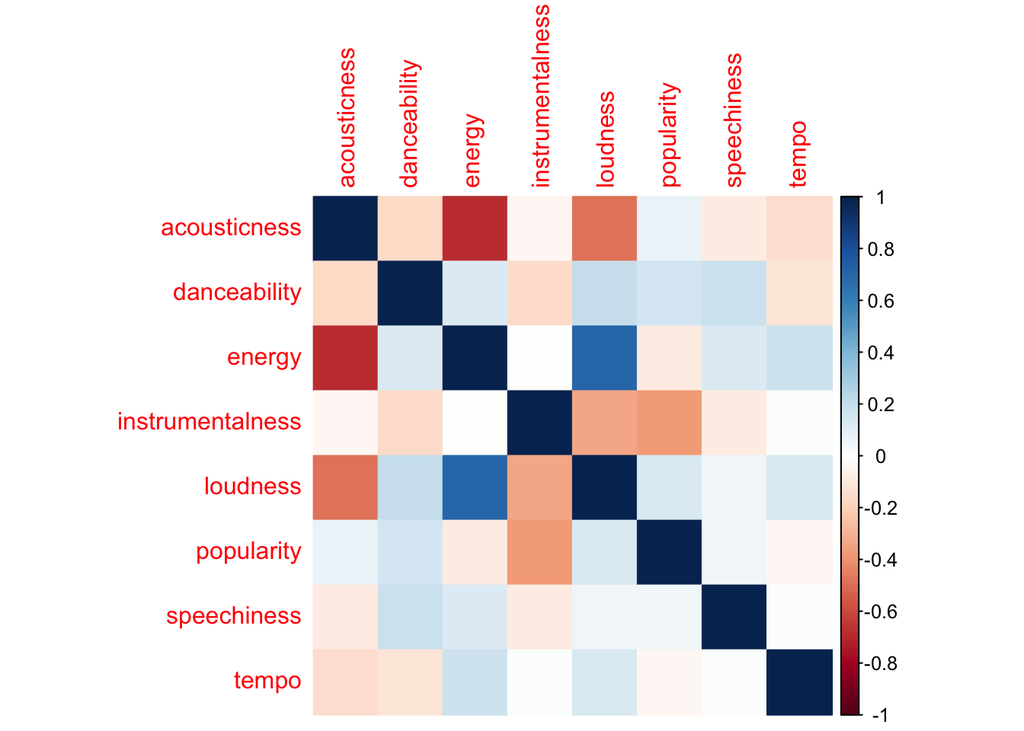

```r
RQ1_relation <- c("popularity", "acousticness", "danceability", "energy", "instrumentalness", "tempo", "loudness", "speechiness")
df1 = subset[RQ1_relation]
RQ2_relation <- c("explicit_fac", "danceability", "energy", "speechiness","tempo")
df2 = subset[RQ2_relation]
cordf1 = cor(df1)
corrplot(cordf1, method = 'color', order = 'alphabet')
```

### Analysis of variables

To better understand the data set, the popularity variable was binned into 5 groups ranging from least popular to more popular across group 1 to group 5.

Popularity Grouping

| Popularity_group | Criteria |
| --- | --- |
| Popularity group 1 | popularity <= 20 |
| Popularity group 2 | popularity <= 40 |
| Popularity group 3 | popularity <= 60 |
| Popularity group 4 | popularity <= 80 |
| Popularity group 4 | popularity <= 100 |

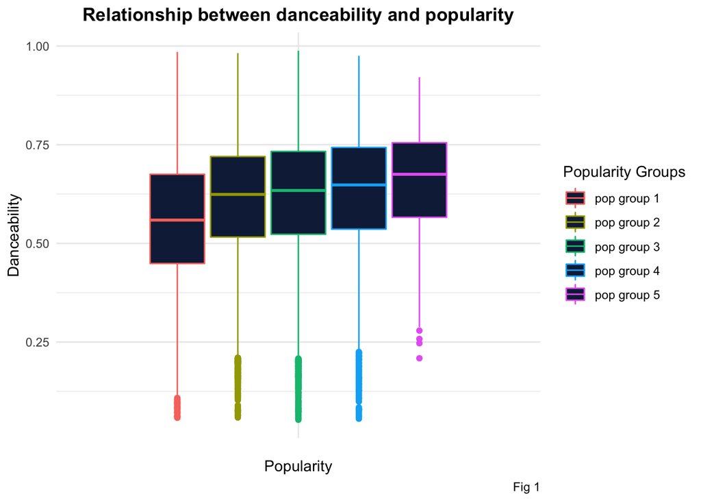

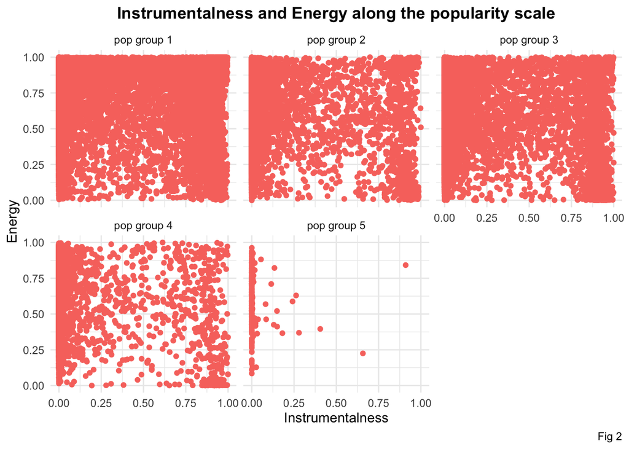

In Figure 1, we observe that more popular songs have a higher average danceability than less popular songs. In Figure 2, we observe that, as songs become more popular, the energy remains evenly distributed, but the instrumentalness is reduced with the exception of a few outliers, although the relationship between the two variables becomes insignificant.

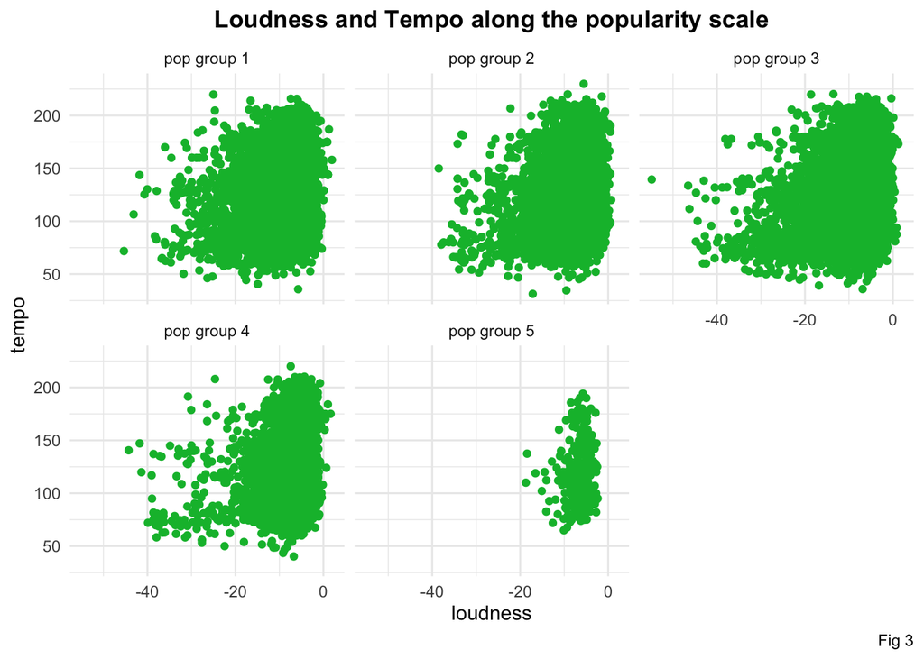

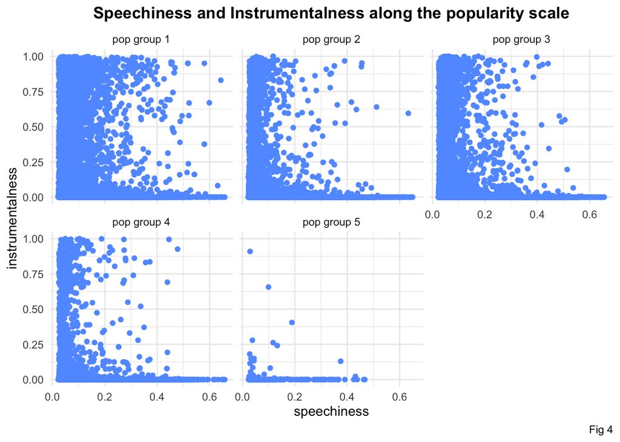

For Figure 3, the relationship between tempo and loudness reveals a very specific recipe for the most popular, chart topping songs. This group’s tempo lies between 50-200 BPM (beats per minute) and -20 to 0 decibles. Meanwhile, other groups’ tempo and loudness profiles remain spread out across the axes of tempo and loudness, unrestricted to a specific quadrant of values. Similarly, for Figure 4, although the speechiness values remain evenly distributed, the most popular songs exhibit a massive reduction in values for instrumentation, while the less popular songs retain a higher spread for instrumentation values. From the above observations, if a song is massively popular (Pop Group 5), the instrumentalness will ultimately be less signficant.

Overall, the insights show that there seems to be an assortment of musical attributes that define an extremely popular song, yet they seem to be less pronounced for the less popular groups of songs. In other words, the most popular song profiles demonstrate an absence of instrumentalness and a specific range of specific tempo and loudness values.

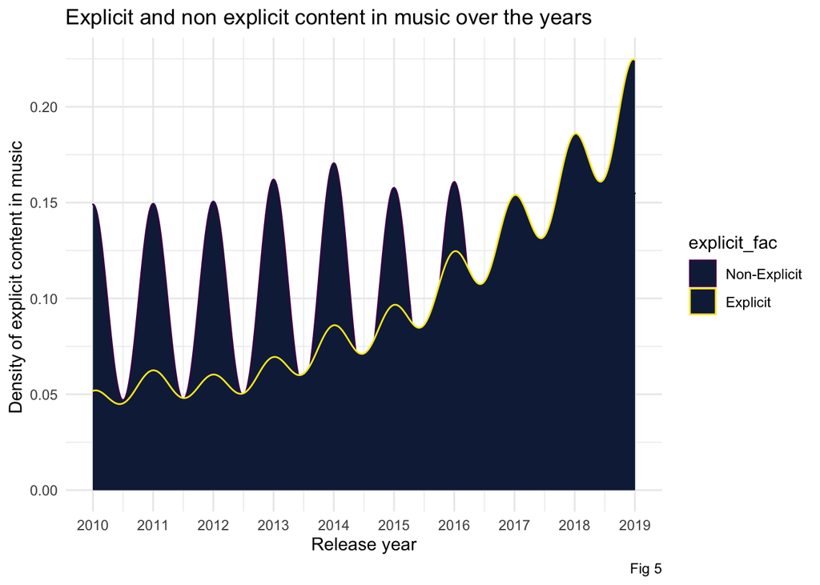

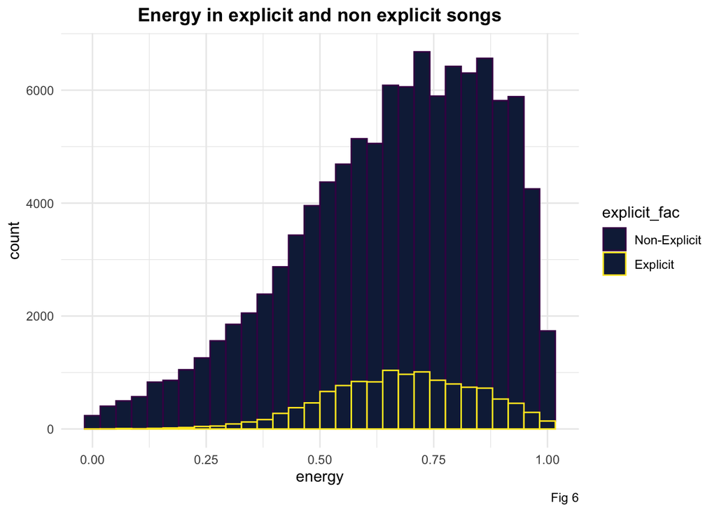

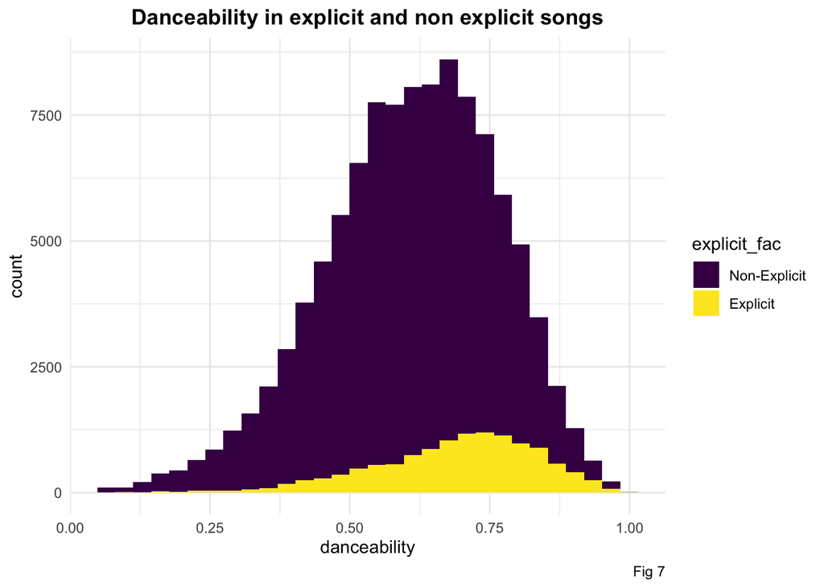

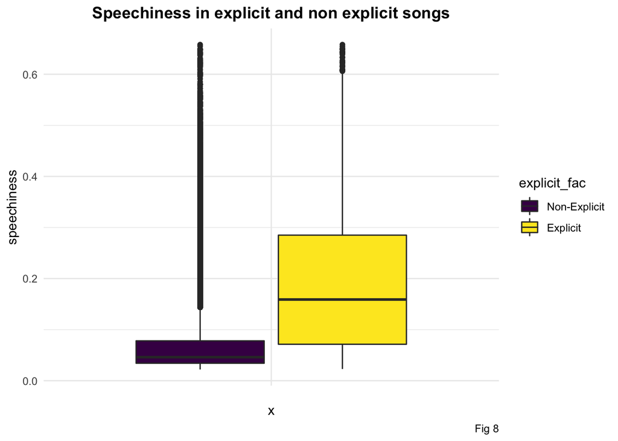

## III.Other characteristics

A few variables such as key and time signature are part of this dataset, although they were not chosen as the predictors. Most of the remaining variables in this dataset pertain to the artist name, the song title, the modalities and key of a song, the duration and the release dates. Nonetheless, some variables were still very rich in information in terms of prediction. To illustrate, one could predict the scale of a song based on the popularity in addition to other predictors.

Some were not chosen because they were differently coded, such as time signature, which has an extremely limited set of plausible values (lacks signatures like 6/8). In contrast, some offered little or irrelevant information. Liveness is one such case. It parametrizes a song’s performance as a live or studio quality recording, and, given that the songs that play on the radio tend to be studio songs, we opted to not use this variable as a predictor.

## IV. Potential Challenges

Eric’s findings from cleaning : Yes, there is a bit of missingness. Some dates have years, but not months and days recorded. This meant that we had to manually fix them or give them arbitrary values. Some artist names are missing, which is notable but currently not obstructive. We also do not know if some of the tempos of the higher songs were incorrectly recorded.

Modifications based on the research questions:

1. Our research question pertains to the songs of the 2010s decade. Hence, post subsetting the original dataset to our research interest, the dataset contains 104767 rows and 23 columns.
2. Bad tempo data in the subset for around 148 tracks have been dropped. The column names depicting are variables of interest and the rows depicting the number of observations.
3. For our first research question we have popularity as dependent variable which is continuous variable. Our second research questions predicts Explicitness(dependent variable) on basis of predictor variables. Explicit here is a categorical variable and hence, we will factor it into non explicit, and explicit.
4. Character was the data type for the dates column. Since the year was our interest, it was extracted into a new column variable as an integer type.
5. Artist names needed the brackets removed. It was cleaned for future use, if looking into artist’s sonic profiles was our interest.
6. The duration variable, which was recorded in milliseconds, was converted to minutes to facilitate easy interpretation.
7. The explicitness variable needed to be factored.
8. For speechiness, values above 0.66 are categorized as speech tracks like podcasts and poetries. Hence, they have been dropped.
9. The tempo variable had values of 0, which is impossible for musical tracks. In addition, we found that tracks with these 0 values were often recordings of white noise, rain sounds, pink noise, intermission songs, and true songs with no tempo data available. These values had to be removed.

## V. Bibliography (Citations)

Androids (2017, October 13). An Idiot’s Guide to EDM Genres. Retrieved October 20, 2022, from https://www.complex.com/music/an-idiots-guide-to-edm-genres/

Burchell, C. (2019, May 27). 10 Tips for Making Your First Trap Beat. Inverse. Retrieved October 20, 2022, from https://flypaper.soundfly.com/produce/10-tips-for-making-your-first-trap-beat/#

Edwords, E. (n.d.). Rap Song Structure Is TOO Important To Ignore. Retrieved October 20, 2022, from https://rhymemakers.com/rap-song-structure/

Leviatan, Y. (2017, July 27). Making Music: The 6 Stages of Music Production. Waves. Retrieved October 20, 2022, from https://www.waves.com/six-stages-of-music-production

Spotify (2022). Spotify Web API Reference | Spotify for Developers. https://developer.spotify.com/documentation/web-api/reference/#/operations/get-audio-features

Tayag, Y. (2017, May 17). Expert on Male Psychology Explains How Pop Got Sexually Explicit. Retrieved October 20, 2022, from https://www.inverse.com/article/31842-pop-music-sexually-explicit-lyrics-rap-hip-hop

Yamac. (2016). Spotify Dataset 1921-2020, 600k+ Tracks. Spotify. Retrieved October 3, 2022, from https://www.kaggle.com/datasets/yamaerenay/spotify-dataset-19212020-600k-tracks